# Wrangling and Summarizing Data

Read this notebook from top to bottom and fill in the code as you go. Work together and discuss with other students in the class. Try to resolve any errors on your own first, but don’t get stuck; ask for help!

In addition to writing and running code, be sure to examine any output and interpret the results before moving on.

For many of these questions, there are several ways to do it in Pandas. You only need to choose one that works. But you might want to experiment with multiple ways of doing the same thing to get practice working with Pandas. However, you should generally try to find the simplest solution. In particular, use `groupby` whenever possible to streamline the code.

```python
import pandas as pd
```

## Titanic data

```python
df_titanic = pd.read_csv("https://raw.githubusercontent.com/kevindavisross/data301/main/data/titanic.csv")
df_titanic
```

|  | name | gender | age | class | embarked | country | ticketno | fare | survived | pclass | crew |
| --- | --- | --- | --- | --- | --- | --- | --- | --- | --- | --- | --- |
| 0 | Abbing, Mr. Anthony | male | 42.0 | 3rd | S | United States | 5547.0 | 7.11 | 0 | 3.0 | NaN |
| 1 | Abbott, Mr. Eugene Joseph | male | 13.0 | 3rd | S | United States | 2673.0 | 20.05 | 0 | 3.0 | NaN |
| 2 | Abbott, Mr. Rossmore Edward | male | 16.0 | 3rd | S | United States | 2673.0 | 20.05 | 0 | 3.0 | NaN |
| 3 | Abbott, Mrs. Rhoda Mary 'Rosa' | female | 39.0 | 3rd | S | England | 2673.0 | 20.05 | 1 | 3.0 | NaN |
| 4 | Abelseth, Miss. Karen Marie | female | 16.0 | 3rd | S | Norway | 348125.0 | 7.13 | 1 | 3.0 | NaN |
| ... | ... | ... | ... | ... | ... | ... | ... | ... | ... | ... | ... |
| 2202 | Wynn, Mr. Walter | male | 41.0 | deck crew | B | England | NaN | NaN | 1 | NaN | deck crew |
| 2203 | Yearsley, Mr. Harry | male | 40.0 | victualling crew | S | England | NaN | NaN | 1 | NaN | victualling crew |
| 2204 | Young, Mr. Francis James | male | 32.0 | engineering crew | S | England | NaN | NaN | 0 | NaN | engineering crew |
| 2205 | Zanetti, Sig. Minio | male | 20.0 | restaurant staff | S | England | NaN | NaN | 0 | NaN | restaurant staff |
| 2206 | Zarracchi, Sig. L. | male | 26.0 | restaurant staff | S | England | NaN | NaN | 0 | NaN | restaurant staff |

2207 rows × 11 columns

1. Create a new variable “type” that takes values either “passenger” or “crew”.

```python
# YOUR CODE HERE.
df_titanic["type"] = df_titanic["class"].map({
    "1st": "passenger",
    "2nd": "passenger",
    "3rd": "passenger",
    "victualling crew": "crew",
    "engineering crew": "crew",
    "deck crew": "crew",
    "restaurant staff": "crew"
})

df_titanic
```

|  | name | gender | age | class | embarked | country | ticketno | fare | survived | pclass | crew | type |
| --- | --- | --- | --- | --- | --- | --- | --- | --- | --- | --- | --- | --- |
| 0 | Abbing, Mr. Anthony | male | 42.0 | 3rd | S | United States | 5547.0 | 7.11 | 0 | 3.0 | NaN | passenger |
| 1 | Abbott, Mr. Eugene Joseph | male | 13.0 | 3rd | S | United States | 2673.0 | 20.05 | 0 | 3.0 | NaN | passenger |
| 2 | Abbott, Mr. Rossmore Edward | male | 16.0 | 3rd | S | United States | 2673.0 | 20.05 | 0 | 3.0 | NaN | passenger |
| 3 | Abbott, Mrs. Rhoda Mary 'Rosa' | female | 39.0 | 3rd | S | England | 2673.0 | 20.05 | 1 | 3.0 | NaN | passenger |
| 4 | Abelseth, Miss. Karen Marie | female | 16.0 | 3rd | S | Norway | 348125.0 | 7.13 | 1 | 3.0 | NaN | passenger |
| ... | ... | ... | ... | ... | ... | ... | ... | ... | ... | ... | ... | ... |
| 2202 | Wynn, Mr. Walter | male | 41.0 | deck crew | B | England | NaN | NaN | 1 | NaN | deck crew | crew |
| 2203 | Yearsley, Mr. Harry | male | 40.0 | victualling crew | S | England | NaN | NaN | 1 | NaN | victualling crew | crew |
| 2204 | Young, Mr. Francis James | male | 32.0 | engineering crew | S | England | NaN | NaN | 0 | NaN | engineering crew | crew |
| 2205 | Zanetti, Sig. Minio | male | 20.0 | restaurant staff | S | England | NaN | NaN | 0 | NaN | restaurant staff | crew |
| 2206 | Zarracchi, Sig. L. | male | 26.0 | restaurant staff | S | England | NaN | NaN | 0 | NaN | restaurant staff | crew |

2207 rows × 12 columns

2. Find the proportion those onboard who were passengers and the proportion who were crew. Do this by creating a Series with these proportions.

```python
# YOUR CODE HERE.
df_titanic["type"].value_counts(normalize=True)
```

```
type
passenger    0.596738
crew         0.403262
Name: proportion, dtype: float64
```

3. Note that “survived” is a categorical variable that has been one-hot encoded as a dummy (aka Bernoulli aka indicator) numerical variable with 1 = survived and 0 = not survived. (Check its dtype.) Find the proportion of those onboard who survived. You could do this with `value_counts` like for “type”, but try a different way that takes advantage of the fact that “survived” is a numerical type. (Hint: what happens if you sum the values of a 1/0 variable? What happens if you take the mean of the values of a 1/0 variable?)

```python
# YOUR CODE HERE.
df_titanic['survived'].mean()
```

```
np.float64(0.3221567739012234)
```

4. Create a crosstab (two-way table) summarizing the joint distribution of “survived” and “type”. (Notice that we can treat the dummy variable “survived” as both a categorical variable and a numerical variable, whichever is convenient.)

```python
# YOUR CODE HERE.
pd.crosstab(df_titanic['survived'], df_titanic['type'])
```

| type survived | crew | passenger |
| --- | --- | --- |
| 0 | 679 | 817 |
| 1 | 211 | 500 |

5. Compare the proportion of passengers who survived and the proportion of crew members who survived. Do this by creating a Series that contains these two proportions. Who was more likely to survive: passengers or crew?

Hint: there are a few ways of doing this, several of which avoid explicitly dividing. Can you take advantage of `groupby` and the fact that “survived” is a dummy variable?

```python
# YOUR CODE HERE.
df_titanic.groupby('type')['survived'].mean()
```

```
type
crew         0.237079
passenger    0.379651
Name: survived, dtype: float64
```

6. The “gender” variable is coded only as “male” or “female”. Among males only, compare the proportion of passengers who survived and the proportion of cew who survived. Among males, who was more likely to survive: passengers or crew? Then do the same thing among females only. Among females, who was more likely to survive: passengers or crew?

Do this by creating a Series that contains the 4 proportions you need. Hint: if you used `groupby` in the previous part you should only need a small change here.

```python
# YOUR CODE HERE.
df_titanic.groupby(['gender','type'])['survived'].mean()
# df_titanic.groupby(['type','gender'])['survived'].mean()
```

```
gender  type
female  crew         0.869565
        passenger    0.727468
male    crew         0.220300
        passenger    0.189189
Name: survived, dtype: float64
```

```python
df_titanic.info()
```

```
<class 'pandas.DataFrame'>
RangeIndex: 2207 entries, 0 to 2206
Data columns (total 12 columns):
 #   Column    Non-Null Count  Dtype
---  ------    --------------  -----
 0   name      2207 non-null   str
 1   gender    2207 non-null   str
 2   age       2205 non-null   float64
 3   class     2207 non-null   str
 4   embarked  2207 non-null   str
 5   country   2126 non-null   str
 6   ticketno  1316 non-null   float64
 7   fare      1291 non-null   float64
 8   survived  2207 non-null   int64
 9   pclass    1317 non-null   float64
 10  crew      890 non-null    str
 11  type      2207 non-null   str
dtypes: float64(4), int64(1), str(7)
memory usage: 207.0 KB
```

7. Compare your answers to 5 and 6. What do you notice? Can you explain why this happens? Suggest an explanation and then create summaries of the data to support your explanation.

```python
# YOUR CODE HERE.
df_titanic.groupby(['gender','type'])['survived'].count()
```

```
gender  type
female  crew          23
        passenger    466
male    crew         867
        passenger    851
Name: survived, dtype: int64
```

```python
df_titanic.groupby(['survived','type'])['gender'].count()
```

```
survived  type
0         crew         679
          passenger    817
1         crew         211
          passenger    500
Name: gender, dtype: int64
```

## College Scorecard

The [College Scorecard](https://collegescorecard.ed.gov/) was an effort started by the U.S. Department of Education to help students make more informed choices about colleges. Data from 2022 is available at https://raw.githubusercontent.com/kevindavisross/data301/refs/heads/main/data/college_scorecard_2022.csv

```python
df_college = pd.read_csv("https://raw.githubusercontent.com/kevindavisross/data301/refs/heads/main/data/college_scorecard_2022.csv")

df_college
```

|  | Institution | City | State | Undergraduates | Median Earnings |
| --- | --- | --- | --- | --- | --- |
| 0 | Alabama A & M University | Normal | AL | 5098.0 | 39059.0 |
| 1 | University of Alabama at Birmingham | Birmingham | AL | 13284.0 | 50907.0 |
| 2 | Amridge University | Montgomery | AL | 251.0 | 37730.0 |
| 3 | University of Alabama in Huntsville | Huntsville | AL | 7358.0 | 56901.0 |
| 4 | Alabama State University | Montgomery | AL | 3495.0 | 34018.0 |
| ... | ... | ... | ... | ... | ... |
| 6538 | Pennsylvania State University-Penn State York | York | PA | NaN | 61185.0 |
| 6539 | Pennsylvania State University-Penn State Great... | Malvern | PA | NaN | 61185.0 |
| 6540 | Pennsylvania State University-Penn State Harri... | Middletown | PA | NaN | 61185.0 |
| 6541 | Pennsylvania State University-Penn State Brand... | Media | PA | NaN | 61185.0 |
| 6542 | Burlington County Institute of Technology - Ad... | Medford | NJ | NaN | NaN |

6543 rows × 5 columns

1. What is the observational unit? Make a guess for how the earnings variable is computed.

2. Write code to find the California Polytechnic row in the data set!

```python
# YOUR CODE HERE
# df_college.select()
california_institutions = df_college[df_college['Institution'].str.contains('California Polytechnic')]
california_institutions
```

|  | Institution | City | State | Undergraduates | Median Earnings |
| --- | --- | --- | --- | --- | --- |
| 194 | California Polytechnic State University-San Lu... | San Luis Obispo | CA | 21090.0 | 85801.0 |

```python
df_college[df_college['City'] == 'San Luis Obispo']
```

|  | Institution | City | State | Undergraduates | Median Earnings |
| --- | --- | --- | --- | --- | --- |
| 194 | California Polytechnic State University-San Lu... | San Luis Obispo | CA | 21090.0 | 85801.0 |
| 262 | Cuesta College | San Luis Obispo | CA | 6961.0 | 46197.0 |
| 4154 | Central California School of Continuing Education | San Luis Obispo | CA | 79.0 | 46527.0 |
| 4800 | Laurus College | San Luis Obispo | CA | 734.0 | 28846.0 |
| 6221 | Columbia College - San Luis Obispo | San Luis Obispo | CA | NaN | 44642.0 |

3. The data set contains information about the median earnings of students who attended each college, 10 years after they first enrolled. The earnings are taken directly from the W2 tax forms of all students who received federal financial aid.

Notice the earnings are missing (NaN). Create a subset data frame that only includes colleges with non-missing earnings. Use this subset to answer the remaining questions.

```python
# YOUR CODE HERE.
df_college2 = df_college[df_college['Median Earnings'].isna() == False]
df_college2['Median Earnings']
```

```
0       39059.0
1       50907.0
2       37730.0
3       56901.0
4       34018.0
         ...
6537    61185.0
6538    61185.0
6539    61185.0
6540    61185.0
6541    61185.0
Name: Median Earnings, Length: 5165, dtype: float64
```

```python
df_college3 = df_college[df_college['Median Earnings'].notna()]
df_college3['Median Earnings']
```

```
0       39059.0
1       50907.0
2       37730.0
3       56901.0
4       34018.0
         ...
6537    61185.0
6538    61185.0
6539    61185.0
6540    61185.0
6541    61185.0
Name: Median Earnings, Length: 5165, dtype: float64
```

4. Summarize the earnings variable, by finding the sample size, mean, SD, and *five number summary* (minimum, 25th percentile, median, 75th percentile, maximum). Hint: you can do all this with a single command! What is larger: the mean or the median? Why? Then create a histogram of the earnings variable.

```python
# YOUR CODE HERE
# df_college.describe()
df_college.describe().round()
```

|  | Undergraduates | Median Earnings |
| --- | --- | --- |
| count | 5769.0 | 5165.0 |
| mean | 2446.0 | 41129.0 |
| std | 5828.0 | 16186.0 |
| min | 0.0 | 11085.0 |
| 25% | 111.0 | 29448.0 |
| 50% | 483.0 | 38696.0 |
| 75% | 2050.0 | 49077.0 |
| max | 119248.0 | 129442.0 |

The mean is larger, which aligns with general earnings distributions because there are often some higher outlier values which skew the mean higher than what the middle 50% of the population actually makes.

5. Create a new column with the log of earnings, then create a histogram. How does the shape of the histogram of log earnings compare to earnings itself?

```python
# YOUR CODE HERE
import numpy as np
from plotnine import *
df_college["Median Earnings"] = np.log(df_college["Median Earnings"])
```

```
Matplotlib is building the font cache; this may take a moment.
```

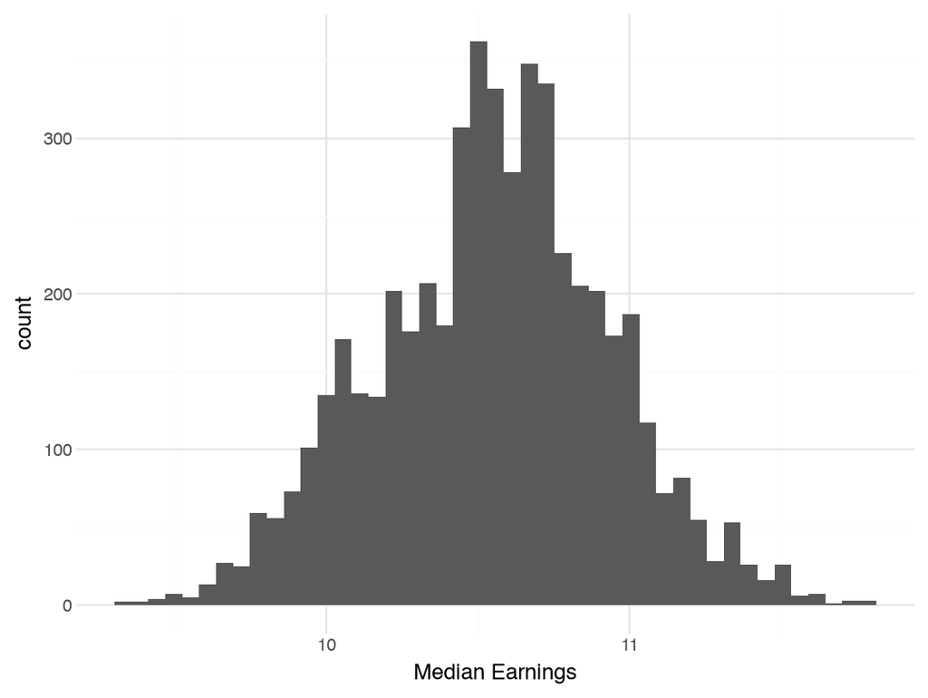

```python
college_hist = (
    ggplot(df_college, aes(x='Median Earnings'))
    + geom_histogram()
    + theme_minimal()
)
college_hist
```

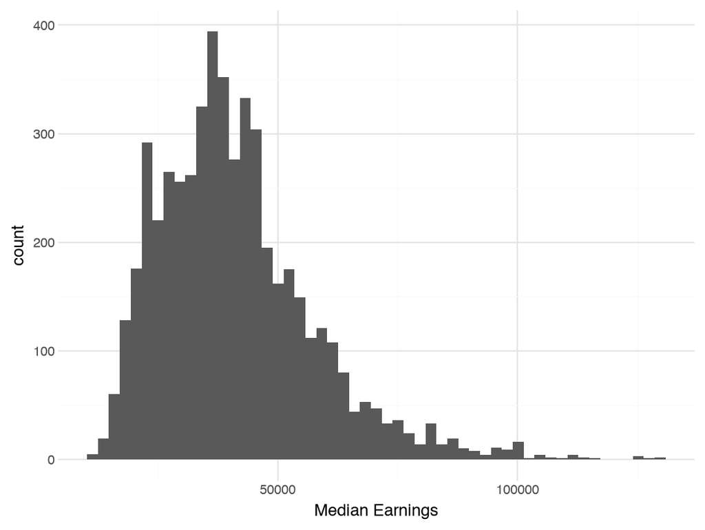

```python
college_hist2 = (
    ggplot(df_college2, aes(x='Median Earnings'))
    + geom_histogram()
    + theme_minimal()
)
college_hist2
```

6. The mean gives every college equal weight. But some colleges are tiny (e.g., San Francisco Conservatory, with 228 undergraduates), while others are large (e.g., Penn State, with 72229 undergraduates!).

If we are interested in what *students* earn, we might want to give more weight to colleges with more students. To do this, we can calculate a **weighted mean**:

$$\sum_{i=1}^n w_i x_i.$$

In general, the weights $w_1, w_2, ..., w_n$ should all be non-negative and should add up to $1.0$. (For the usual mean, every observation gets equal weight, $1/n$.)

Calculate a weighted mean of earnings, using the undergraduate enrollments as weights. Do this by first adding a “weight” column to the data set (number of undegraduates for the college divided by the total number of undergraduates in the data set).

```python
# YOUR CODE HERE
df_college2['weight'] = df_college2['Undergraduates'] / df_college2['Undergraduates'].sum()
```

7. Compute the mean of earnings for each state. Sort the states in descending order of mean earnings. Display the results in a bar chart.

```python
# YOUR CODE HERE.
df_state = df_college2.groupby('State')['Median Earnings'].mean().sort_values(ascending=False)
df_state
```

```
State
MA    56633.768519
VT    53040.230769
RI    52605.947368
DC    51325.470588
CT    50771.413793
NH    49322.333333
NY    48752.694352
WA    47733.266667
PA    47607.290210
MN    45855.938776
NJ    44964.081081
CA    44461.812371
MD    44454.342857
NE    43776.868421
AK    43604.500000
WI    43417.909091
ME    43400.032258
IN    43311.268519
IL    42443.338624
HI    42162.437500
OR    41934.816667
IA    41809.521127
VA    41803.976744
MO    41702.425197
CO    41578.523077
KS    41244.690141
NV    41184.741935
SD    41136.608696
AZ    40854.298851
DE    40319.153846
OH    40115.951613
ND    39603.080000
VI    39307.000000
WY    38966.300000
GA    38845.460526
AL    38225.338028
TX    38074.490683
MI    37855.232394
MT    37653.480000
NC    37178.948387
NM    36994.588235
TN    36866.411290
SC    36446.682927
FL    36162.099668
UT    35862.604651
WV    35782.507937
OK    35564.678161
KY    35171.828571
MH    34483.000000
LA    34087.642857
AR    32972.202703
ID    32823.666667
MS    31897.104167
PW    31212.000000
GU    31082.000000
AS    28524.000000
MP    25107.000000
FM    23377.000000
PR    22257.669173
Name: Median Earnings, dtype: float64
```

8. Repeat the previous part, but now compute a weighted mean of earnings for each state, using the number of undegraduate enrollments in the state as weights. (Hint: use `groupby` with `transform`.)

```python
# YOUR CODE HERE.
df_college2['state_total_undergrad'] = df_college2.groupby('State')['Undergraduates'].transform('sum')
df_college2['state_weight'] = df_college2['Undergraduates'] / df_college2['state_total_undergrad']
df_college2['weighted_earnings'] = df_college2['state_weight'] * df_college2['Median Earnings']

df_state_weighted = df_college2.groupby('State')['weighted_earnings'].sum().sort_values(ascending=False)
df_state_weighted
```

```
State
DC    69939.367698
MA    65365.038613
RI    61382.901051
VT    58815.822129
CT    58515.071887
PA    58152.366783
NY    57869.188381
DE    56136.291687
MD    56049.152616
WA    55332.820949
NH    55043.032070
NJ    54956.421801
UT    54274.369021
ND    53733.319895
VA    53265.020364
MN    53257.575881
WI    52622.024037
IL    52567.618773
CA    51861.217937
IA    51723.723529
NE    51268.810074
CO    50724.480712
OR    50632.035920
IN    50227.922229
MI    50057.879324
WV    50012.392262
MO    49111.791894
TX    48719.078342
ID    48550.410338
HI    48235.746445
AK    47484.939237
SD    47463.984742
GA    47246.144980
KS    47195.607294
ME    47025.392744
NV    46974.859922
FL    46868.957171
OH    46457.828084
SC    46361.251566
AZ    46269.729336
MT    46245.688158
AL    46235.575067
WY    45676.820836
NC    45554.928093
OK    45200.927650
TN    44455.268088
LA    43624.414206
KY    42942.305706
AR    42616.774237
VI    39307.000000
MS    38593.953921
NM    38089.932224
MH    34483.000000
GU    32092.752281
PW    31212.000000
AS    28524.000000
PR    26105.497420
MP    25107.000000
FM    23377.000000
Name: weighted_earnings, dtype: float64
```

## Olympic Men’s Gymnastics Data

The file https://raw.githubusercontent.com/mshsu/probasets/refs/heads/main/data/OlympicAllAround.csv contains scores from the qualification and final rounds of the Olympic men’s gymnastics all around competition from 2008 to 2020. (Thanks to Martin Hsu for scraping this data set.)

```python
df_gym = pd.read_csv("https://raw.githubusercontent.com/mshsu/probasets/refs/heads/main/data/OlympicAllAround.csv")

df_gym
```

|  | Pos | Gymnast | NOC | Points | Floor Exercise | Horse Vault | Parallel Bars | Horizontal Bar | Rings | Pommelled Horse | Round | Year |
| --- | --- | --- | --- | --- | --- | --- | --- | --- | --- | --- | --- | --- |
| 0 | 1.0 | Danell Leyva | USA | 91.265 | 15.100 | 15.500 | 15.333 | 15.866 | 14.600 | 14.866 | Qualification | 2012 |
| 1 | 2.0 | David Belyavsky | RUS | 90.832 | 15.100 | 16.300 | 15.300 | 14.866 | 14.366 | 14.900 | Qualification | 2012 |
| 2 | 3.0 | Fabian HambÃ¼chen | GER | 90.765 | 15.133 | 15.833 | 15.300 | 15.633 | 14.766 | 14.100 | Qualification | 2012 |
| 3 | 4.0 | John Orozco | USA | 90.597 | 15.166 | 15.800 | 14.533 | 15.266 | 15.066 | 14.766 | Qualification | 2012 |
| 4 | 5.0 | Kristian Thomas | GBR | 90.256 | 15.366 | 16.200 | 14.625 | 15.366 | 14.566 | 14.133 | Qualification | 2012 |
| ... | ... | ... | ... | ... | ... | ... | ... | ... | ... | ... | ... | ... |
| 346 | 20.0 | Daniel Keatings | GBR | 89.000 | 14.850 | 15.800 | 14.425 | 14.225 | 14.000 | 15.700 | Final | 2008 |
| 347 | 21.0 | Thomas Bouhail | FRA | 87.000 | 15.200 | 15.850 | 14.425 | 14.475 | 13.650 | 13.400 | Final | 2008 |
| 348 | 22.0 | José Luis Fuentes | VEN | 86.300 | 14.175 | 15.250 | 15.175 | 14.150 | 13.900 | 13.650 | Final | 2008 |
| 349 | 23.0 | Dzmitry Savitski | BLR | 82.175 | 13.725 | 15.900 | 13.400 | 10.100 | 15.300 | 13.750 | Final | 2008 |
| 350 | 24.0 | Chen Yibing | CHN | 74.225 | NaN | 15.900 | 14.950 | 12.975 | 16.650 | 13.750 | Final | 2008 |

351 rows × 12 columns

1. Create a data frame

- With [Round, Year, Gymnast] as the (multi) index, and
- Containing only the six columns with the event scores, “Floor Exercise” through “Pommelled Horse”

```python
# YOUR CODE HERE.
event_cols = ['Floor Exercise', 'Horse Vault', 'Parallel Bars', 'Horizontal Bar', 'Rings', 'Pommelled Horse']

df_gym = df_gym.set_index(['Round', 'Year', 'Gymnast'])[event_cols]
df_gym
```

| Round | Year | Gymnast | Floor Exercise | Horse Vault | Parallel Bars | Horizontal Bar | Rings | Pommelled Horse |
| --- | --- | --- | --- | --- | --- | --- | --- | --- |
| Qualification | 2012 | Danell Leyva | 15.100 | 15.500 | 15.333 | 15.866 | 14.600 | 14.866 |
|  |  | David Belyavsky | 15.100 | 16.300 | 15.300 | 14.866 | 14.366 | 14.900 |
|  |  | Fabian HambÃ¼chen | 15.133 | 15.833 | 15.300 | 15.633 | 14.766 | 14.100 |
|  |  | John Orozco | 15.166 | 15.800 | 14.533 | 15.266 | 15.066 | 14.766 |
|  |  | Kristian Thomas | 15.366 | 16.200 | 14.625 | 15.366 | 14.566 | 14.133 |
| ... | ... | ... | ... | ... | ... | ... | ... | ... |
| Final | 2008 | Daniel Keatings | 14.850 | 15.800 | 14.425 | 14.225 | 14.000 | 15.700 |
|  |  | Thomas Bouhail | 15.200 | 15.850 | 14.425 | 14.475 | 13.650 | 13.400 |
|  |  | José Luis Fuentes | 14.175 | 15.250 | 15.175 | 14.150 | 13.900 | 13.650 |
|  |  | Dzmitry Savitski | 13.725 | 15.900 | 13.400 | 10.100 | 15.300 | 13.750 |
|  |  | Chen Yibing | NaN | 15.900 | 14.950 | 12.975 | 16.650 | 13.750 |

351 rows × 6 columns

2. Summarize the scores for each of the six events, by finding the sample size, mean, SD, and *five number summary* (minimum, 25th percentile, median, 75th percentile, maximum). Hint: you can do all this with a single command!

```python
# YOUR CODE HERE
df_gym.describe()
```

|  | Floor Exercise | Horse Vault | Parallel Bars | Horizontal Bar | Rings | Pommelled Horse |
| --- | --- | --- | --- | --- | --- | --- |
| count | 324.000000 | 323.000000 | 323.000000 | 324.000000 | 318.000000 | 325.000000 |
| mean | 14.309133 | 14.976551 | 14.719288 | 14.082562 | 14.237799 | 13.816723 |
| std | 1.254009 | 0.959876 | 0.920044 | 1.299542 | 0.914523 | 1.242348 |
| min | 1.633000 | 11.766000 | 10.200000 | 0.000000 | 7.700000 | 0.000000 |
| 25% | 13.866000 | 14.300000 | 14.233000 | 13.475000 | 13.700000 | 13.266000 |
| 50% | 14.500000 | 15.058000 | 14.900000 | 14.300000 | 14.275000 | 13.925000 |
| 75% | 15.033000 | 15.700000 | 15.350000 | 14.854000 | 14.831000 | 14.566000 |
| max | 15.950000 | 16.775000 | 16.425000 | 16.200000 | 16.650000 | 16.000000 |

3. There are 351 rows in the data frame. Why are the sample sizes different for each event, and not all equal to 351?

**Not every gymnast in the data completed all six events. Some athletes were injured mid-competition and had to withdraw before finishing, while others didn’t intend on competing in every single event to begin with. This is why each event’s sample size was a bit less than 351, and varied between groups.**

4. In the all around competition, each gymnast competes all six events, but this doesn’t always happen (due to injury, etc). Therefore, there are some missing values in the data. Most of the missing values are coded as `NaN` but some are coded as 0. What would be a more appropriate way to code the missing values in this case: `NaN` or 0? Why?

**Nan feels like the appropriate way to do things because if someone misses out on an event, coding it as a 0 would drag down the averages unecessarily. If someone did a banned move or got disqualified during the event, which resulted in an actual 0, that is where that would be appropriate.**

5. Replace all scores of 0 in the data frame with `NaN`. (Note: It is possible to actually score a 0 on some events, e.g., if you do a vault but don’t land feet first. But the few 0s in this data set are for people who didn’t compete the event at all.)

```python
# YOUR CODE HERE
df_gym = df_gym.replace(0, np.nan)
df_gym
```

| Round | Year | Gymnast | Floor Exercise | Horse Vault | Parallel Bars | Horizontal Bar | Rings | Pommelled Horse |
| --- | --- | --- | --- | --- | --- | --- | --- | --- |
| Qualification | 2012 | Danell Leyva | 15.100 | 15.500 | 15.333 | 15.866 | 14.600 | 14.866 |
|  |  | David Belyavsky | 15.100 | 16.300 | 15.300 | 14.866 | 14.366 | 14.900 |
|  |  | Fabian HambÃ¼chen | 15.133 | 15.833 | 15.300 | 15.633 | 14.766 | 14.100 |
|  |  | John Orozco | 15.166 | 15.800 | 14.533 | 15.266 | 15.066 | 14.766 |
|  |  | Kristian Thomas | 15.366 | 16.200 | 14.625 | 15.366 | 14.566 | 14.133 |
| ... | ... | ... | ... | ... | ... | ... | ... | ... |
| Final | 2008 | Daniel Keatings | 14.850 | 15.800 | 14.425 | 14.225 | 14.000 | 15.700 |
|  |  | Thomas Bouhail | 15.200 | 15.850 | 14.425 | 14.475 | 13.650 | 13.400 |
|  |  | José Luis Fuentes | 14.175 | 15.250 | 15.175 | 14.150 | 13.900 | 13.650 |
|  |  | Dzmitry Savitski | 13.725 | 15.900 | 13.400 | 10.100 | 15.300 | 13.750 |
|  |  | Chen Yibing | NaN | 15.900 | 14.950 | 12.975 | 16.650 | 13.750 |

351 rows × 6 columns

6. Summarize the revised data. Which events tend to have the highest scores? The lowest? Which events have the greatest degree of variability in scores? The least?

```python
# YOUR CODE HERE
df_gym.describe()
```

|  | Floor Exercise | Horse Vault | Parallel Bars | Horizontal Bar | Rings | Pommelled Horse |
| --- | --- | --- | --- | --- | --- | --- |
| count | 324.000000 | 323.000000 | 323.000000 | 323.000000 | 318.000000 | 324.000000 |
| mean | 14.309133 | 14.976551 | 14.719288 | 14.126161 | 14.237799 | 13.859367 |
| std | 1.254009 | 0.959876 | 0.920044 | 1.037426 | 0.914523 | 0.977423 |
| min | 1.633000 | 11.766000 | 10.200000 | 9.433000 | 7.700000 | 10.666000 |
| 25% | 13.866000 | 14.300000 | 14.233000 | 13.475000 | 13.700000 | 13.266000 |
| 50% | 14.500000 | 15.058000 | 14.900000 | 14.300000 | 14.275000 | 13.925000 |
| 75% | 15.033000 | 15.700000 | 15.350000 | 14.858000 | 14.831000 | 14.574500 |
| max | 15.950000 | 16.775000 | 16.425000 | 16.200000 | 16.650000 | 16.000000 |

**7**. Compute the correlation matrix. For which pairs of events is the correlation the highest? The lowest?

```python
# YOUR CODE HERE
df_gym.corr()
```

|  | Floor Exercise | Horse Vault | Parallel Bars | Horizontal Bar | Rings | Pommelled Horse |
| --- | --- | --- | --- | --- | --- | --- |
| Floor Exercise | 1.000000 | 0.440092 | 0.351537 | 0.378685 | 0.494417 | 0.289385 |
| Horse Vault | 0.440092 | 1.000000 | 0.383301 | 0.500211 | 0.595005 | 0.367616 |
| Parallel Bars | 0.351537 | 0.383301 | 1.000000 | 0.557611 | 0.589963 | 0.481337 |
| Horizontal Bar | 0.378685 | 0.500211 | 0.557611 | 1.000000 | 0.491114 | 0.449014 |
| Rings | 0.494417 | 0.595005 | 0.589963 | 0.491114 | 1.000000 | 0.420985 |
| Pommelled Horse | 0.289385 | 0.367616 | 0.481337 | 0.449014 | 0.420985 | 1.000000 |

8. Standardize the scores for each of the six events by subtracting the mean for the event and dividing by its standard deviation. Note: you can do this for all six events at once. You should NOT write a for loop or create a separate line of code for each event.

```python
# YOUR CODE HERE
df_gym_std = (df_gym - df_gym.mean()) / df_gym.std()
df_gym_std
```

| Round | Year | Gymnast | Floor Exercise | Horse Vault | Parallel Bars | Horizontal Bar | Rings | Pommelled Horse |
| --- | --- | --- | --- | --- | --- | --- | --- | --- |
| Qualification | 2012 | Danell Leyva | 0.630671 | 0.545330 | 0.667047 | 1.677073 | 0.396055 | 1.029884 |
|  |  | David Belyavsky | 0.630671 | 1.378771 | 0.631179 | 0.713149 | 0.140184 | 1.064669 |
|  |  | Fabian HambÃ¼chen | 0.656987 | 0.892250 | 0.631179 | 1.452479 | 0.577570 | 0.246191 |
|  |  | John Orozco | 0.683303 | 0.857870 | -0.202477 | 1.098718 | 0.905610 | 0.927574 |
|  |  | Kristian Thomas | 0.842791 | 1.274591 | -0.102482 | 1.195111 | 0.358877 | 0.279953 |
| ... | ... | ... | ... | ... | ... | ... | ... | ... |
| Final | 2008 | Daniel Keatings | 0.431311 | 0.857870 | -0.319863 | 0.095273 | -0.260025 | 1.883148 |
|  |  | Thomas Bouhail | 0.710416 | 0.909960 | -0.319863 | 0.336254 | -0.642738 | -0.469978 |
|  |  | José Luis Fuentes | -0.106963 | 0.284879 | 0.495316 | 0.022979 | -0.369372 | -0.214203 |
|  |  | Dzmitry Savitski | -0.465812 | 0.962050 | -1.433940 | -3.880914 | 1.161481 | -0.111893 |
|  |  | Chen Yibing | NaN | 0.962050 | 0.250762 | -1.109632 | 2.637661 | -0.111893 |

351 rows × 6 columns

9. The all around champion is whoever has the highest total score for the six events (in the finals). But who is the “all around standardized value champion”? Create a column that sums the standardized values for each athlete, then sort the data frame in descending order by that column. Note: you should NOT have to manually add six columns.

```python
# YOUR CODE HERE
df_gym_std['Total Standardized'] = df_gym_std.sum(axis=1)
df_gym_std.sort_values('Total Standardized', ascending=False)
```

| Round | Year | Gymnast | Floor Exercise | Horse Vault | Parallel Bars | Horizontal Bar | Rings | Pommelled Horse | Total Standardized |
| --- | --- | --- | --- | --- | --- | --- | --- | --- | --- |
| Final | 2008 | Yang Wei | 0.750288 | 1.639221 | 1.500703 | 0.625432 | 2.610324 | 1.448331 | 8.574298 |
| Qualification | 2008 | Yang Wei | 0.869904 | 1.639221 | 0.685524 | 0.770020 | 2.172938 | 1.601796 | 7.739403 |
| Final | 2012 | Kohei Uchimura | 0.630671 | 1.343350 | 0.658351 | 1.420669 | 1.197566 | 1.234504 | 6.485111 |
| Qualification | 2008 | Kim Dae-Eun | 0.949648 | 1.118320 | 1.446357 | 0.480843 | 1.325501 | 0.885627 | 6.206298 |
|  |  | Li Xiaopeng | 0.630671 | 1.873626 | 1.853947 | 1.227884 | 0.614748 | NaN | 6.200877 |
|  | ... | ... | ... | ... | ... | ... | ... | ... | ... |
|  | 2020 | Uche Eke | -1.177131 | -1.608074 | -2.702358 | -2.531420 | -2.556304 | -1.016312 | -11.591600 |
|  |  | David Huddleston | -1.496108 | -1.017372 | -1.688276 | -2.564194 | -2.228264 | -2.925414 | -11.919628 |
|  |  | Hung Yuan-Hsi | -0.858154 | -2.094595 | -3.499060 | -1.085534 | -1.754793 | -3.164819 | -12.456954 |
|  |  | David Rumbutis | -1.709025 | -1.954993 | -3.245811 | -1.535687 | -3.321730 | -1.868553 | -13.635800 |
|  |  | Jeremiah Loo | -0.964214 | -2.615495 | -4.912036 | -2.275016 | -7.148862 | -1.630171 | -19.545795 |

351 rows × 7 columns

10. Compute the mean score for each event in each year. How do the means change over time? Why do you think this happened?

```python
# YOUR CODE HERE.
df_gym.groupby(level='Year')[event_cols].mean()
```

| Year | Floor Exercise | Horse Vault | Parallel Bars | Horizontal Bar | Rings | Pommelled Horse |
| --- | --- | --- | --- | --- | --- | --- |
| 2008 | 14.720250 | 15.841753 | 15.125758 | 14.563750 | 14.850532 | 14.248750 |
| 2012 | 14.495154 | 15.484308 | 14.663231 | 14.365922 | 14.441462 | 13.787172 |
| 2016 | 14.134667 | 14.496068 | 14.787083 | 14.246315 | 14.201514 | 14.051319 |
| 2020 | 13.841989 | 14.046398 | 14.242529 | 13.336919 | 13.453632 | 13.312341 |

11. Choose one event and for that event create a plot with a single panel that summarizes the distribution of scores for each of the four years. Describe what you see.

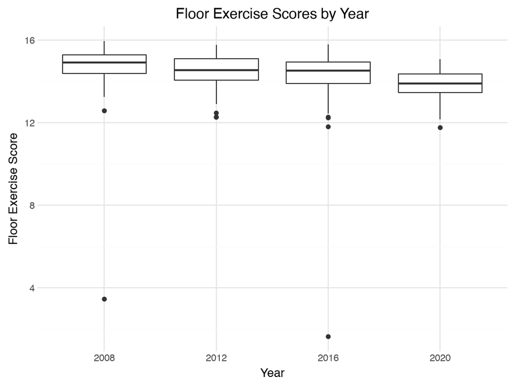

```python
# YOUR CODE HERE.
df_gym_reset_index = df_gym.reset_index()

(
    ggplot(df_gym_reset_index, aes(x='factor(Year)', y='Floor Exercise'))
    + geom_boxplot()
    + theme_minimal()
    + labs(x='Year', y='Floor Exercise Score', title='Floor Exercise Scores by Year')
)
```

12. Standardize the scores for each of the six events by subtracting the mean for the event and dividing by its standard deviation *within each year*. Note: you can do this for all six events at once. You should NOT write a for loop or create a separate line of code for each event.

```python
# YOUR CODE HERE.
df_gym_std_year = df_gym.groupby(level='Year').transform(lambda x: (x - x.mean()) / x.std())
df_gym_std_year
```

| Round | Year | Gymnast | Floor Exercise | Horse Vault | Parallel Bars | Horizontal Bar | Rings | Pommelled Horse |
| --- | --- | --- | --- | --- | --- | --- | --- | --- |
| Qualification | 2012 | Danell Leyva | 0.753096 | 0.027915 | 1.002995 | 1.708332 | 0.269011 | 1.232874 |
|  |  | David Belyavsky | 0.753096 | 1.451057 | 0.953577 | 0.569503 | -0.128045 | 1.271729 |
|  |  | Fabian HambÃ¼chen | 0.794185 | 0.620298 | 0.953577 | 1.442985 | 0.550683 | 0.357497 |
|  |  | John Orozco | 0.835273 | 0.561594 | -0.195024 | 1.025035 | 1.059729 | 1.118595 |
|  |  | Kristian Thomas | 1.084294 | 1.273164 | -0.057251 | 1.138917 | 0.211319 | 0.395209 |
| ... | ... | ... | ... | ... | ... | ... | ... | ... |
| Final | 2008 | Daniel Keatings | 0.098864 | -0.076907 | -0.896615 | -0.385333 | -1.098537 | 1.745577 |
|  |  | Thomas Bouhail | 0.365547 | 0.015192 | -0.896615 | -0.100954 | -1.550593 | -1.020884 |
|  |  | José Luis Fuentes | -0.415455 | -1.089993 | 0.063005 | -0.470647 | -1.227696 | -0.720182 |
|  |  | Dzmitry Savitski | -0.758335 | 0.107290 | -2.208096 | -5.077583 | 0.580528 | -0.599901 |
|  |  | Chen Yibing | NaN | 0.107290 | -0.224881 | -1.807227 | 2.324171 | -0.599901 |

351 rows × 6 columns

13. If we standardize within each year, which athletes (and rounds and year) had the highest total standardized values? Basically repeat part 9 but with standardization within each year.

```python
# YOUR CODE HERE.
df_gym_std_year['Total Standardized'] = df_gym_std_year.sum(axis=1)
df_gym_std_year.sort_values('Total Standardized', ascending=False)
```

| Round | Year | Gymnast | Floor Exercise | Horse Vault | Parallel Bars | Horizontal Bar | Rings | Pommelled Horse | Total Standardized |
| --- | --- | --- | --- | --- | --- | --- | --- | --- | --- |
| Final | 2016 | Oleh Verniaiev | 0.520383 | 1.475149 | 1.524323 | 0.534169 | 2.005141 | 1.554973 | 7.614139 |
|  | 2012 | Kohei Uchimura | 0.753096 | 1.390574 | 0.991015 | 1.405403 | 1.512779 | 1.461432 | 7.514300 |
| Qualification | 2020 | Daiki Hashimoto | 1.196662 | 1.341947 | 1.007048 | 1.915265 | 0.443776 | 1.488590 | 7.393287 |
| Final | 2020 | Daiki Hashimoto | 1.382156 | 1.070152 | 1.007048 | 1.802342 | 0.085413 | 1.898201 | 7.245313 |
| Qualification | 2016 | Oleh Verniaiev | 0.404528 | 0.837441 | 1.600950 | 0.855432 | 1.822604 | 1.589606 | 7.110561 |
|  | ... | ... | ... | ... | ... | ... | ... | ... | ... |
|  | 2008 | Mohamed Srour | -0.967872 | -0.951845 | -3.519576 | -0.499085 | -2.809891 | -1.201306 | -9.949575 |
|  | 2020 | David Rumbutis | -2.337488 | -1.549551 | -2.389868 | -0.907808 | -2.425281 | -1.310083 | -10.920078 |
|  | 2016 | KÃ©vin Crovetto | -0.739543 | -1.954366 | -2.423146 | -1.524613 | -2.437804 | -2.362683 | -11.442155 |
|  | 2008 | Brandon O'Neill | -8.587414 | -1.274190 | -0.288855 | NaN | NaN | -2.133483 | -12.283942 |
|  | 2020 | Jeremiah Loo | -1.034845 | -2.587608 | -3.849770 | -1.773927 | -6.191859 | -1.071484 | -16.509494 |

351 rows × 7 columns